# Semi- and non-parametric time series models

26 Feb 2019

## Overview of today's material

- Gaussian processes for time series
- Neural networks
- EDM

## Gaussian processes for time series

Last week, we discussed exponential smoothing and in lab touched on GAMs

- Both approaches are similar in that they borrow information from neighbors
- Exponential smoothing usually borrows information from past data for forecasting
- Generalized additive models (GAMs) usually borrow information from both future and past data

## Gaussian processes for time series

GAMs estimate the *trend* using a smooth function,

\[E\left[ Y \right] ={ B }_{ 0 }+f(x)\]

where like regression, we assume \(Y\sim Normal\left( E\left[ Y \right] ,\sigma \right)\)

- The smooth function approximates the trend at a smaller subset of locations (aka *knots*)
- The density and location of the knots can affect how 'wiggly' the function is

## Gaussian processes for time series

For data that are regularly spaced in time, this probably isn't a big deal

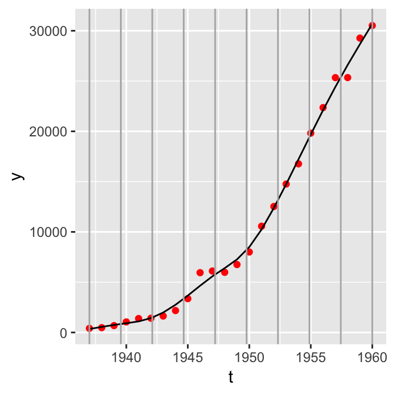

- This fit looks pretty reasonable

## Gaussian processes for time series

Let's try again, this time knocking a few holes in the data. Removing years 1950:1953 and 1955:1959, the knot locations are no longer equally spaced, and weighted more toward the locations of data points.

- Greater spacing between knots = less flexibility, more uncertainty (you can look at the 'se.fit' part of predict output)

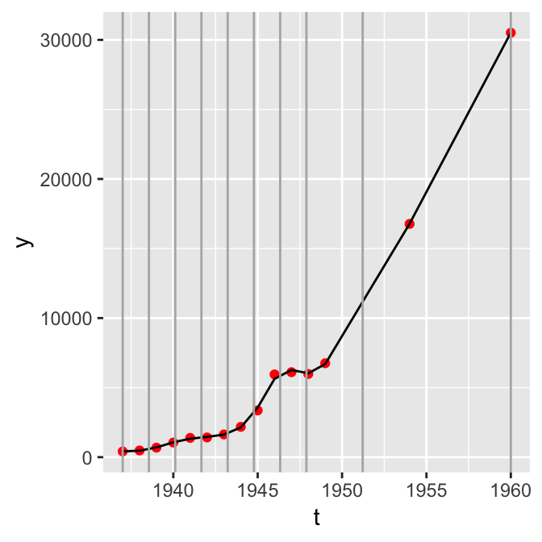

## Gaussian processes for time series

Recapping, GAMs are estimating the underlying *trend* using a smooth function,

\[E\left[ Y \right] ={ B }_{ 0 }+f(x)\]

- It's important to note that this underlying trend function \(f(x)\) is modeling the **mean**
- Smooths are very flexible (with respect to # knots, locations, smooth type). See 'mgcv' and 'gamm'

We're going to leave GAMs alone for now, but there's lots of great references out there. Examples:

- Gavin Simpson's work with GAMs and time series [here](https://www.biorxiv.org/content/10.1101/322248v1)
- Simon Wood's book

## Gaussian processes for time series

Similarities between GAMs and GP models:

- GAMs and GP predictive models use reduced dimensionality (knots) to constrain flexibility

Differences:

- GAMs use smooth functions & knot locations to constrain how neighbors affect mean
- GP models use covariance function to control how much neighbors can influence eachother based on how far apart they are